# Model verification

Nils Kehrein

31 March, 2025

## Introduction

This document aims at verifying the implementation of the *Lemna* toxicokinetic-toxicodynamic (TKTD) model as described by *Klein et al.* (2022). The model is a refined description of the *Lemna* TKTD model based on *Schmitt et al. (2013)*.

First, this model’s output is compared to published results which were created with the reference implementation of the *Schmitt et al.* model. For unlimited growth scenarios, both models are expected to yield identical results for identical inputs. Second, model dynamics are compared for additional scenarios which simulate changing environmental conditions, such as under field study conditions. In this case, the models are not expected to yield identical but equivalent behavior due to differences between the models’ response functions.

## Schmitt et al. model

The outputs of the *Lemna* TKTD model by *Schmitt et al.* are used to verify the implementation of the *Klein et al.* model. The reference implementation of *Schmitt et al.* is included in this package’s GitHub repository but is not an official part of the package.

Sourcing files `mmc2.r` and `mmc3.r` gives access to the *Schmitt et al.* model equations as well as to the fitted parameter set for the substance *metsulfuron-methyl*.

```r
library(lemna)   # lemna model
# load packages to ease plotting and data wrangling
library(dplyr)   # for data preparation
library(ggplot2) # for plotting

# load model files by Schmitt et al. (2013)
source("mmc2.r")
source("mmc3.r")

# run sample simulation with metsulfuron-methyl parameters
calcgrowth(timepoints = 0:7,
           vars = c(BM = 0.0012, E=1, M_int=0),
           param = param, # default scenario data
           )
```

```
#>   time          BM       M_int     C_int  FrondNo
#> 1    0 0.001200000 0.000000000 0.0000000 12.00000
#> 2    1 0.001284774 0.005436458 0.2533803 12.84774
#> 3    2 0.001306316 0.009105453 0.4173850 13.06316
#> 4    3 0.001314398 0.011494598 0.5236614 13.14398
#> 5    4 0.001320074 0.013044177 0.5917003 13.20074
#> 6    5 0.001324988 0.014053436 0.6351173 13.24988
#> 7    6 0.001329581 0.014716554 0.6627886 13.29581
#> 8    7 0.001334016 0.015158319 0.6804143 13.34016
```

## Unlimited growth scenarios

This section simulates several *Lemna* growth scenarios under unlimited growth conditions using the *Klein et al.* model. Model dynamics and numerical results are compared to results of the *Schmitt et al.* model.

### Seven days exposure, seven days recovery

Figure 2 in *Schmitt et al.* (2013) presents several scenarios which simulate the growth of *Lemna* exposed to several concentrations of *metsulfuron-methyl*. Exposure lasts for seven days, followed by a seven day recovery period. Symbols show observed data and lines as calculated with fitted model parameters.

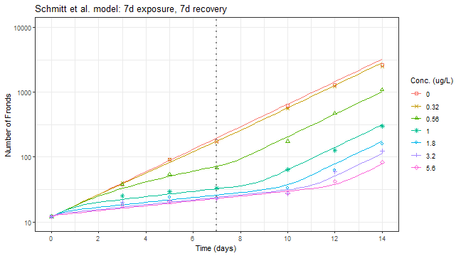

```r
# simulate the 7d exposure, 7d recovery experiment
simulate_7d <- function(model=c("schmitt","klein"), ...) {
  model <- match.arg(model)
  time <- seq(0, 14, 0.2) # output time points
  levels <- c(0, 0.32, 0.56, 1, 1.8, 3.2, 5.6) # simulated exposure levels

  # set parameters as needed to replicate Figure 2 from Schmitt et al.
  if(model == "schmitt") {
    param$k_phot_fix <- TRUE # unlimited growth
    param$k_phot_max <- 0.4
    param$k_resp <- 0
  } else if(model == "klein") {
    param <- metsulfuron$param
    param$k_photo_fixed <- TRUE
    param$k_photo_max <- 0.4
    param$k_loss <- 0
    envir <- metsulfuron$envir
  }

  result <- data.frame()
  for(conc in levels) {
    exposure <- data.frame(time=c(0, 7, 7.01, 14), c=c(conc, conc, 0, 0))

    if(model == "schmitt") {
      param$Conc <- exposure
      out <- calcgrowth(time, c(BM=0.0012, E=1, M_int=0), param=param, ...)
    } else if(model == "klein") {
      envir$conc <- exposure
      out <- lemna(times=time, init=c(BM=0.0012, M_int=0), param=param, envir=envir, ode_mode="c", ...)
    }

    out$level = as.character(conc)
    result <- bind_rows(result, out)
  }
  result
}

# simulate using the Schmitt et al. model
df_s <- simulate_7d(model="schmitt")

# recreate figure 2 from paper, including observed data
ggplot(df_s)+
  geom_line(aes(time,FrondNo,color=level))+
  geom_point(aes(time,FrondNo,color=level,shape=level), data=schmitt77)+
  scale_y_log10(breaks=10^seq(-1,6))+
  scale_x_continuous(breaks=seq(0,14,2))+
  scale_shape_manual(values=c(0,4,2,8,1,3,5), name="Conc. (ug/L)")+
  coord_cartesian(ylim=c(10,10000))+
  geom_vline(xintercept=7, linetype="dotted", color="#888888", size=1)+
  geom_segment(x=0,y=10000,xend=6.9,yend=10000,arrow=arrow(length=unit(0.3,"cm"),type="closed"),linejoin="mitre",size=1,color="#888888")+
  geom_segment(x=7.1,y=10000,xend=14,yend=10000,arrow=arrow(length=unit(0.3,"cm"),type="closed"),linejoin="mitre",size=1,color="#888888")+
  geom_text(x=3.5,y=8000,label="Exposure",hjust="middle",color="#888888")+
  geom_text(x=10.5,y=8000,label="Recovery",hjust="middle",color="#888888")+
  theme_bw()+
  labs(x="Time (days)", y="Number of Fronds", color="Conc. (ug/L)",
       title="Schmitt et al. model: 7d exposure, 7d recovery")
```

The depicted model dynamics of the *Schmitt et al.* are identical to published results. Simulating the same scenarios using the *Klein et al.* model yields identical dynamics:

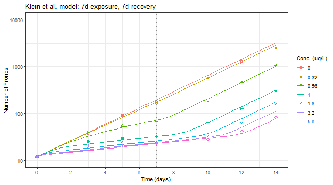

```r
# simulate using the Klein et al. model
df_k <- simulate_7d(model="klein")

# recreate figure 2 from paper, including observed data
ggplot(df_k)+
  geom_line(aes(time,FrondNo,color=level))+
  geom_point(aes(time,FrondNo,color=level,shape=level), data=schmitt77)+
  scale_y_log10(breaks=10^seq(-1,6))+
  scale_x_continuous(breaks=seq(0,14,2))+
  scale_shape_manual(values=c(0,4,2,8,1,3,5), name="Conc. (ug/L)")+
  coord_cartesian(ylim=c(10,10000))+
  geom_vline(xintercept=7, linetype="dotted", color="#888888", size=1)+
  geom_segment(x=0,y=10000,xend=6.9,yend=10000,arrow=arrow(length=unit(0.3,"cm"),type="closed"),linejoin="mitre",size=1,color="#888888")+
  geom_segment(x=7.1,y=10000,xend=14,yend=10000,arrow=arrow(length=unit(0.3,"cm"),type="closed"),linejoin="mitre",size=1,color="#888888")+
  geom_text(x=3.5,y=8000,label="Exposure",hjust="middle",color="#888888")+
  geom_text(x=10.5,y=8000,label="Recovery",hjust="middle",color="#888888")+
  theme_bw()+
  labs(x="Time (days)", y="Number of Fronds", color="Conc. (ug/L)",
       title="Klein et al. model: 7d exposure, 7d recovery")
```

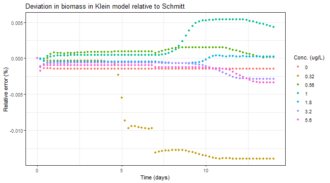

```r
df_s %>%
  mutate(error = 100 * (df_k$BM/BM - 1)) %>%
  ggplot(aes(time, error, color=level)) +
  geom_point() +
  theme_bw() +
  labs(x="Time (days)", y="Relative error (%)", color="Conc. (ug/L)",
       title="Deviation in biomass in Klein model relative to Schmitt")
```

The deviations are a result of imprecisions introduced by the numerical ODE solver. Numerical precision can be increased by, for example, decreasing the solver’s step length in time. This can be achieved by decreasing the solver parameter `hmax` from the model’s default value of `hmax=0.1` to e.g. `hmax=0.01`. The value of `0.01` is equivalent to a step length of about 15 minutes. This decreases the observed deviations significantly to a maximum of about 0.007%:

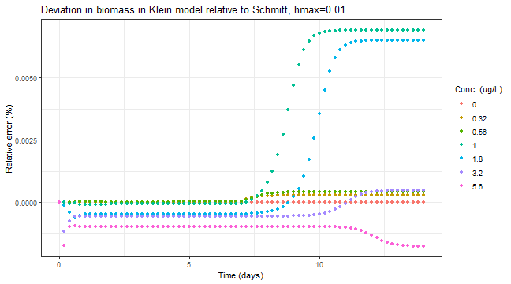

```r
df_s <-  simulate_7d(model="schmitt", hmax=0.01)
df_k <-  simulate_7d(model="klein", hmax=0.01)

df_s %>%
  mutate(error = 100 * (df_k$BM/BM - 1)) %>%
  ggplot(aes(time, error, color=level)) +
  geom_point() +
  theme_bw() +
  labs(x="Time (days)", y="Relative error (%)", color="Conc. (ug/L)",
       title="Deviation in biomass in Klein model relative to Schmitt, hmax=0.01")
```

It can be concluded that model dynamics and numerical results are identical as far as numerical precision allows.

### Two days of exposure, twelve days of recovery

The right-hand side of Figure 3 in *Hommen et al.* (2015) presents additional scenarios which simulate the growth of *Lemna* exposed to several concentrations of *metsulfuron-methyl*. Exposure lasts for two days, followed by a twelve day recovery period. Symbols show observed data and lines as calculated with fitted model parameters:

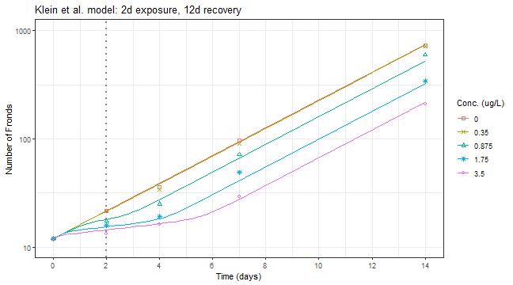

```r
# simulate the 2d exposure, 12d recovery experiment
simulate_2d <- function(model=c("schmitt","klein"), ...) {
  model <- match.arg(model)
  time <- seq(0, 14, 0.2) # output time points
  levels <- c(0, 0.35, 0.875, 1.75, 3.5) # simulated exposure levels

  # set parameters as needed to replicate Figure 3 from Hommen et al.
  if(model == "schmitt") {
    param$k_phot_fix <- TRUE # unlimited growth
    param$k_phot_max <- 0.295
    param$k_resp <- 0.00
    param$mass_per_frond <- 0.0004
  } else if(model == "klein") {
    param <- metsulfuron$param
    param$k_photo_fixed <- TRUE
    param$k_photo_max <- 0.295
    param$k_loss <- 0
    param$r_DW_FN <- 0.0004
    envir <- metsulfuron$envir
  }

  result <- data.frame()
  for(conc in levels) {
    exposure <- data.frame(time=c(0, 2, 2.01, 14), c=c(conc, conc, 0, 0))

    if(model == "schmitt") {
      param$Conc <- exposure
      out <- calcgrowth(time, c(BM=12 * param$mass_per_frond, E=1, M_int=0), param=param, ...)
    } else if(model == "klein") {
      envir$conc <- exposure
      out <- lemna(times=time, init=c(BM=12 * param$r_DW_FN, M_int=0), param=param, envir=envir, ode_mode="c", ...)
    }

    out$level = as.character(conc)
    result <- bind_rows(result, out)
  }
  result
}

# simulate using the Klein et al. model
df_k <- simulate_2d(model="klein")

# recreate figure 3 from paper, including observed data
ggplot(df_k)+
  geom_line(aes(time,FrondNo,color=level))+
  geom_point(aes(time,FrondNo,color=level,shape=level), data=hommen212)+
  scale_y_log10(breaks=10^seq(-1,6))+
  scale_x_continuous(breaks=seq(0,14,2))+
  scale_shape_manual(values=c(0,4,2,8,1,3,5), name="Conc. (ug/L)")+
  coord_cartesian(ylim=c(10,1000))+
  geom_vline(xintercept=2, linetype="dotted", color="#888888", size=1)+
  geom_segment(x=0,y=1000,xend=1.9,yend=1000,arrow=arrow(length=unit(0.3,"cm"),type="closed"),linejoin="mitre",size=1,color="#888888")+
  geom_segment(x=2.1,y=1000,xend=14,yend=1000,arrow=arrow(length=unit(0.3,"cm"),type="closed"),linejoin="mitre",size=1,color="#888888")+
  geom_text(x=1,y=800,label="Exposure",hjust="middle",color="#888888")+
  geom_text(x=8,y=800,label="Recovery",hjust="middle",color="#888888")+
  theme_bw()+
  labs(x="Time (days)", y="Number of Fronds", color="Conc. (ug/L)",
       title="Klein et al. model: 2d exposure, 12d recovery")
```

Observed model dynamics of the *Klein et al.* model are identical to published results and fit equally well with the observed frond numbers reported by *Hommen et al.* A comparison of numerical values of simulated biomass yields:

```r
# simulate using the Schmitt et al. model
df_s <-  simulate_2d(model="schmitt", hmax=0.01)
# simulate using the Klein et al. model
df_k <-  simulate_2d(model="klein", hmax=0.01)

# calculate relative
df_s %>%
  mutate(error = 100 * (df_k$BM/BM - 1)) %>%
  pull(error) %>%
  abs() %>%
  max()
```

```
#> [1] 0.004476714
```

Numerical biomass values deviate at most by about 0.004% between the two models. It can be concluded that model dynamics and numerical results of both models are identical for the presented scenarios.

### Complex exposure patterns

Figure 4 in *Schmitt et al.* (2013) depicts the growth of *Lemna* exposed to three exposure patterns of several different concentrations. The patterns include constant exposure, repeating intervals of four days out of seven of exposure, as well as repeating intervals of two days out of seven of exposure.

First, the constant exposure pattern (Figure 4a) is simulated:

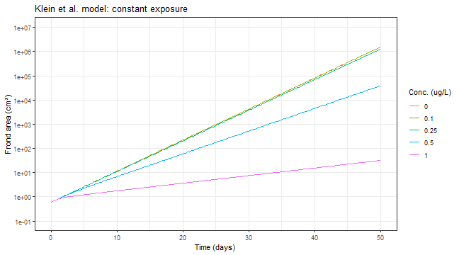

```r
# simulate a specific exposure pattern
simulate_pattern <- function(model=c("schmitt","klein"), levels, expo_fun, ...) {
  model <- match.arg(model)
  time <- seq(0, 50, 0.2) # output time points

  # set parameters as needed to replicate Figure 2 from Schmitt et al.
  if(model == "schmitt") {
    param$k_phot_fix <- TRUE # unlimited growth
    param$k_phot_max <- 0.295
    param$EC50 <- 0.39
    param$k_resp <- 0
  } else if(model == "klein") {
    param <- metsulfuron$param
    param$k_photo_fixed <- TRUE
    param$k_photo_max <- 0.295
    param$EC50_int <- 0.39
    param$k_loss <- 0
    envir <- metsulfuron$envir
  }

  result <- data.frame()
  for(conc in levels) {
    exposure <- expo_fun(conc)

    if(model == "schmitt") {
      param$Conc <- exposure
      out <- calcgrowth(time, c(BM=0.0006, E=1, M_int=0), param=param, hmax=0.01)
      out$Area <- out$BM * param$AperBM
    } else if(model == "klein") {
      envir$conc <- exposure
      out <- lemna(times=time, init=c(BM=0.0006, M_int=0), param=param, envir=envir, hmax=0.01, ode_mode="c")
      out$Area <- out$BM * param$r_A_DW
    }

    out$level = as.character(conc)
    result <- bind_rows(result, out)
  }
  result
}

# constant exposure
expo_const <- function(conc=1) {
  data.frame(time=c(0, 50), c=c(conc, conc))
}
# exposure concentrations used for constant patterns
levels_const <- c(0, 0.1, 0.25, 0.5, 1)

# simulate constant exposure patterns
df_p1 <- simulate_pattern(model="klein", levels=levels_const, expo_fun=expo_const)

ggplot(df_p1)+
  geom_line(aes(time,Area,color=level))+
  scale_y_log10(breaks=10^seq(-1,7),minor_breaks=NULL)+
  scale_x_continuous(breaks=seq(0,50,10))+
  scale_shape_manual(values=c(0,4,2,8,1,3,5))+
  coord_cartesian(ylim=c(0.1,10^7))+
  theme_bw()+
  labs(x="Time (days)", y="Frond area (cm²)", color="Conc. (ug/L)",
       title="Klein et al. model: constant exposure")
```

Next, the four out of seven days exposure pattern (Figure 4b) is simulated:

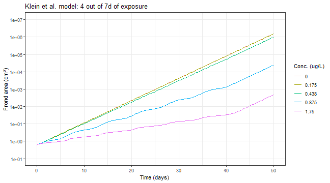

```r
# exposure pattern: repeats 4d exposure, 3d recovery for 42 days,
# followed by recovery for 8 days
expo_4of7 <- function(conc=1) {
  tim <- c(0,       4, 4.01, 6.99)
  exp <- c(conc, conc,    0,    0)

  tim_all <- c()
  exp_all <- c()
  for(i in seq(0,35, 7)) {
    tim_all <- c(tim_all, tim+i)
    exp_all <- c(exp_all, exp)
  }
  data.frame("time"=c(tim_all, 50), "conc"=c(exp_all, 0))
}
# exposure concentrations used for 4 out of 7d patterns
levels_4of7 <- c(0, 0.175, 0.438, 0.875, 1.75)

df_p2 <- simulate_pattern(model="klein", levels=levels_4of7, expo_fun=expo_4of7)

ggplot(df_p2)+
  geom_line(aes(time,Area,color=level))+
  scale_y_log10(breaks=10^seq(-1,7),minor_breaks=NULL)+
  scale_x_continuous(breaks=seq(0,50,10))+
  scale_shape_manual(values=c(0,4,2,8,1,3,5))+
  coord_cartesian(ylim=c(0.1,10^7))+
  theme_bw()+
  labs(x="Time (days)", y="Frond area (cm²)", color="Conc. (ug/L)",
       title="Klein et al. model: 4 out of 7d of exposure")
```

Finally, the two out of seven days exposure pattern (Figure 4c) is simulated:

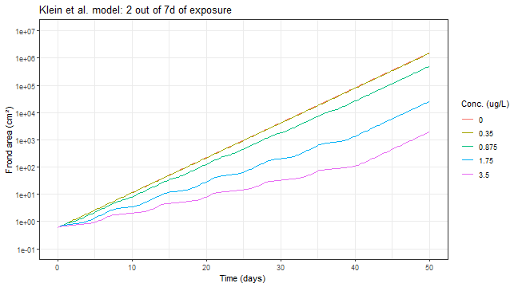

```r
# exposure pattern: repeats 2d exposure, 5d recovery for 42 days,
# followed by recovery for 8 days
expo_2of7 <- function(conc=1) {
  tim <- c(0,       2, 2.01, 6.99)
  exp <- c(conc, conc,    0,    0)

  tim_all <- c()
  exp_all <- c()
  for(i in seq(0,35, 7)) {
    tim_all <- c(tim_all, tim+i)
    exp_all <- c(exp_all, exp)
  }
  data.frame("time"=c(tim_all, 50), "conc"=c(exp_all, 0))
}
# exposure concentrations used for 2 out of 7d patterns
levels_2of7 <- c(0, 0.35, 0.875, 1.75, 3.5)

df_p3 <- simulate_pattern(model="klein", levels=levels_2of7, expo_fun=expo_2of7)

ggplot(df_p3)+
  geom_line(aes(time,Area,color=level))+
  scale_y_log10(breaks=10^seq(-1,7),minor_breaks=NULL)+
  scale_x_continuous(breaks=seq(0,50,10))+
  scale_shape_manual(values=c(0,4,2,8,1,3,5))+
  coord_cartesian(ylim=c(0.1,10^7))+
  theme_bw()+
  labs(x="Time (days)", y="Frond area (cm²)", color="Conc. (ug/L)",
       title="Klein et al. model: 2 out of 7d of exposure")
```

Comparing numerical results of the *Klein et al.* model with the *Schmitt et al.* implementation yields the following relative errors in percent:

```r
# relative error (%) for the constant exposure pattern
simulate_pattern(model="schmitt", levels=levels_const, expo_fun=expo_const) %>%
  mutate(error = 100 * (df_p1$BM/BM - 1)) %>%
  pull(error) %>%
  abs() %>%
  max()
```

```
#> [1] 0.0005302434
```

```r
# relative error (%) for the 4 out of 7d exposure pattern
simulate_pattern(model="schmitt", levels=levels_4of7, expo_fun=expo_4of7) %>%
  mutate(error = 100 * (df_p2$BM/BM - 1)) %>%
  pull(error) %>%
  abs() %>%
  max()
```

```
#> [1] 0.03496461
```

```r
# relative error (%) for the 2 out of 7d exposure pattern
simulate_pattern(model="schmitt", levels=levels_2of7, expo_fun=expo_2of7) %>%
  mutate(error = 100 * (df_p3$BM/BM - 1)) %>%
  pull(error) %>%
  abs() %>%
  max()
```

```
#> [1] 0.02197463
```

It can be observed that the *Klein et al.* model reproduces the same model dynamics and biomass amounts as reported by *Schmitt et al.* under unlimited growth conditions.

## Environmental variability scenarios

The following graphs will replicate Figure 5 from *Hommen et al.* (2015). The simulations make use of exposure time series and time series of environmental variables that were extracted from the three FOCUS Surface Water exposure scenarios *D1 Ditch*, *D2 Ditch*, and *R3 Stream*. Substance specific parameters follow the fitted parameters reported by *Schmitt et al.* (2013).

### FOCUS D1 Ditch

The following code simulates *Lemna* population growth for the example FOCUS exposure pattern D1 Ditch multiplied by factors from 1 to 100:

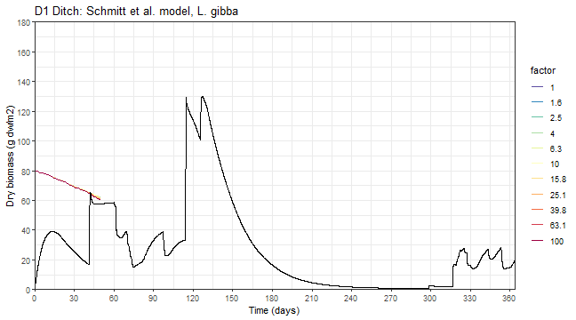

```r
library(tidyr)  # for additional data preparation
library(furrr)  # for multi-threading capabilities

# enable multithreading to reduce processing time
future::plan("multisession")

rainbow_plot <- function(df, exposure, scale_f, title) {
  df$factor <- factor(as.character(df$factor), levels=as.character(unique(sort(df$factor))))
   # scale exposure concentration to make it visible in plot
  df_expo <- exposure %>% mutate(Conc = Conc * scale_f)
  # do not plot control
  df_plot <- df %>% filter(factor != "0")
  # create rainbow plot
  ggplot(df_plot)+
    geom_line(aes(time, BM, color=factor))+
    geom_line(aes(Time,Conc), data=df_expo, color="black")+
    scale_color_manual(values=rev(RColorBrewer::brewer.pal(11, "Spectral")))+
    scale_y_continuous(breaks=seq(0,200,20))+
    scale_x_continuous(breaks=seq(0,390,30))+
    coord_cartesian(ylim=c(0,180),expand=FALSE)+
    theme_bw()+
    labs(x="Time (days)", y="Dry biomass (g dw/m2)", title=title)
}

simulate_focus <- function(scale_f, model, scenario) {
  if(model == "schmitt") {
    param$k_phot_fix <- FALSE
    param$mass_per_frond <- 0.0004
    param$Conc <- scenario$envir$conc
    param$Conc$Conc <- param$Conc$Conc * scale_f
    param$Temp <- scenario$envir$tmp
    param$Rad <- scenario$envir$irr
    res <- calcgrowth(scenario$times, c(BM=scenario$init[["BM"]], E=1, M_int=0), param, hmax=0.01)
  } else if(model == "klein") {
    envir <- scenario$envir
    envir$conc$Conc <- envir$conc$Conc * scale_f
    res <- lemna(scenario, envir=envir, nout=0, hmax=0.01, ode_mode="c")
  }
  res$factor <- scale_f
  res
}

# multiplication factors for the exposure series
factors <- c(0, round(10^seq(0,2,0.2), 1))

# simulate using the Schmitt et al. model
df_s <- future_map_dfr(factors, simulate_focus, model="schmitt", scenario=focusd1)
rainbow_plot(df_s, focusd1$envir$conc, 2000, "D1 Ditch: Schmitt et al. model, L. gibba")
```

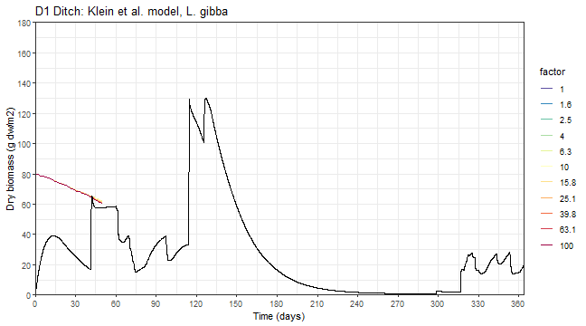

```r
# simulate using the Klein et al. model
df_k <- future_map_dfr(factors, simulate_focus, model="klein", scenario=focusd1)
rainbow_plot(df_k, focusd1$envir$conc, 2000, "D1 Ditch: Klein et al. model, L. gibba")
```

```r
bm_dev_plot <- function(res_klein, res_schmitt, title) {
  fs <- unique(res_klein$factor)

  res_schmitt %>%
    mutate(error = 100 * (res_klein$BM/BM - 1)) %>%
    ggplot(aes(time, error, color=factor)) +
    geom_point() +
    scale_color_manual(values=setNames(c("black",rev(RColorBrewer::brewer.pal(length(fs) - 1, "Spectral"))), fs)) +
    scale_x_continuous(breaks=seq(0,390,30)) +
    theme_bw() +
    labs(x="Time (days)", y="Relative error (%)", color="Factor",
         title=paste0(title, ": Deviation of biomass in Klein model relative to Schmitt"))
}

bm_dev_plot(df_k, df_s, "D1 Ditch")
```

[output not shown]

The following table reproduces Table 2 from *Hommen et al.* (2015). It lists the number of days with deviations from controls exceeding different magnitudes (% dev) depending on the exposure multiplication factor in the D1 Ditch scenario:

```r
df_k %>%
  pivot_wider(id_cols=time, names_from=factor, values_from=BM) -> df.wide

# table of days with deviations
(100*abs(1 - df.wide[-c(1,2)]/df.wide[,c(rep(2,11))])) %>%
  pivot_longer(1:11, names_to="factor", values_to="dev") %>%
  group_by(factor) %>%
  summarize(gt1=sum(dev>1),gt5=sum(dev>5),gt10=sum(dev>10),gt20=sum(dev>20),
            gt30=sum(dev>30),gt40=sum(dev>40),gt50=sum(dev>50),gt60=sum(dev>60),
            gt70=sum(dev>70),gt80=sum(dev>80),gt90=sum(dev>90)) %>%
  arrange(as.numeric(factor)) %>%
  pivot_longer(cols=2:11, names_to="class", values_to="count") %>%
  pivot_wider(id_cols=class, names_from=factor, values_from=count) %>%
  mutate(class = paste0("> ",substring(class, 3))) %>%
  rename(`% dev`=class) %>%
  knitr::kable()
```

| % dev | 1 | 1.6 | 2.5 | 4 | 6.3 | 10 | 15.8 | 25.1 | 39.8 | 63.1 | 100 |
| --- | --- | --- | --- | --- | --- | --- | --- | --- | --- | --- | --- |
| > 1 | 0 | 0 | 0 | 0 | 0 | 0 | 2 | 8 | 9 | 10 | 10 |
| > 5 | 0 | 0 | 0 | 0 | 0 | 0 | 0 | 0 | 0 | 0 | 0 |
| > 10 | 0 | 0 | 0 | 0 | 0 | 0 | 0 | 0 | 0 | 0 | 0 |
| > 20 | 0 | 0 | 0 | 0 | 0 | 0 | 0 | 0 | 0 | 0 | 0 |
| > 30 | 0 | 0 | 0 | 0 | 0 | 0 | 0 | 0 | 0 | 0 | 0 |
| > 40 | 0 | 0 | 0 | 0 | 0 | 0 | 0 | 0 | 0 | 0 | 0 |
| > 50 | 0 | 0 | 0 | 0 | 0 | 0 | 0 | 0 | 0 | 0 | 0 |
| > 60 | 0 | 0 | 0 | 0 | 0 | 0 | 0 | 0 | 0 | 0 | 0 |
| > 70 | 0 | 0 | 0 | 0 | 0 | 0 | 0 | 0 | 0 | 0 | 0 |
| > 80 | 0 | 0 | 0 | 0 | 0 | 0 | 0 | 0 | 0 | 0 | 0 |

### FOCUS D2 Ditch

Simulating *Lemna* population growth for the example FOCUS exposure pattern D2 Ditch multiplied by factors from 1 to 100:

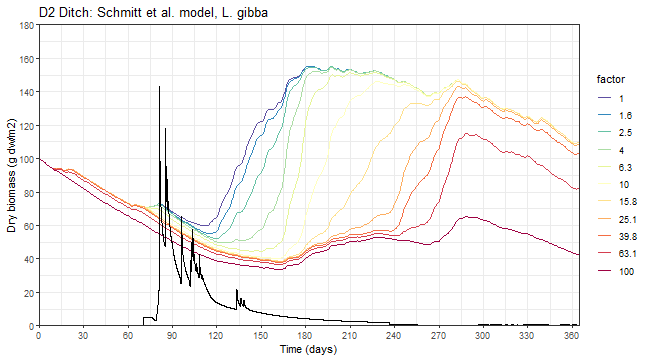

```r
# simulate using the Schmitt et al. model
df_s <- future_map_dfr(factors, simulate_focus, model="schmitt", scenario=focusd2)
rainbow_plot(df_s, focusd2$envir$conc, 100, "D2 Ditch: Schmitt et al. model, L. gibba")
```

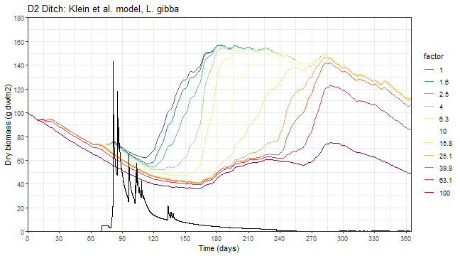

```r
# simulate using the Klein et al. model
df_k <- future_map_dfr(factors, simulate_focus, model="klein", scenario=focusd2)
rainbow_plot(df_k, focusd2$envir$conc, 100, "D2 Ditch: Klein et al. model, L. gibba")
```

```r
bm_dev_plot(df_k, df_s, "D2 Ditch")
```

[output not shown]

### FOCUS R3 Stream

Simulating *Lemna* population growth for the example FOCUS exposure pattern R3 Stream multiplied by factors from 1 to 1000:

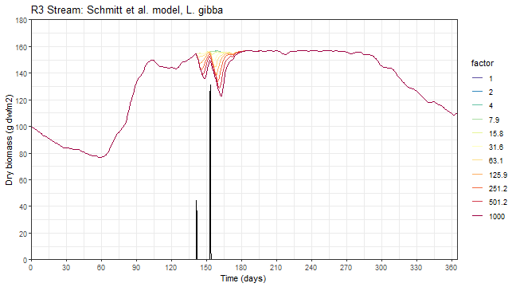

```r
# multiplication factors for the exposure series
factors <- c(0, round(10^seq(0,3,0.3), 1))

# simulate using the Schmitt et al. model
df_s <- future_map_dfr(factors, simulate_focus, model="schmitt", scenario=focusr3)
rainbow_plot(df_s, focusr3$envir$conc, 1000, "R3 Stream: Schmitt et al. model, L. gibba")
```

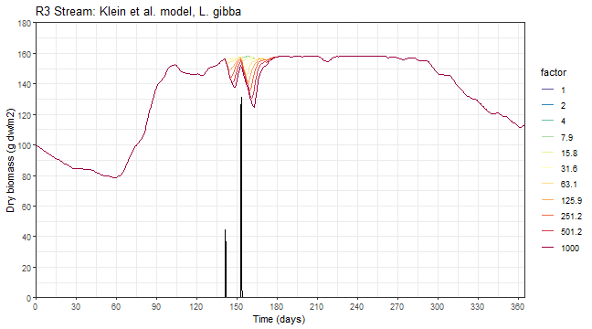

```r
# simulate using the Klein et al. model
df_k <- future_map_dfr(factors, simulate_focus, model="klein", scenario=focusr3)
rainbow_plot(df_k, focusr3$envir$conc, 1000, "R3 Stream: Klein et al. model, L. gibba")
```

```r
bm_dev_plot(df_k, df_s, "R3 Stream")
```

[output not shown]

```r
# disable multithreading
future::plan("sequential")
```

Again, biomass dynamics and absolute numbers are very similar to the behavior reported by *Hommen et al.* (2015) with a small trend towards a larger biomass in the *Klein et al.* model.

## Compiled code

Model equations implemented as compiled code in *C* are not part of this verification document for reasons of brevity. However, results of the *C* code are identical as far as numerical precision allows. This is ensured by automated unit tests which are shipped as part of the *lemna* source package. The suite of verification tests can be run manually by:

```r
devtools::test(pkg="lemna", filter="verify")
```

## Acknowledgements

The author would like to thank U. Hommen and S. Heine for providing the original data sets and scripts which were used for past publications, as well as J. Klein and J. Witt for their feedback and suggestions.

## References

- Hommen U., Schmitt W., Heine S., Brock Theo C.M., Duquesne S., Manson P., Meregalli G., Ochoa-Acuña H., van Vliet P., Arts G., 2015: How TK-TD and Population Models for Aquatic Macrophytes Could Support the Risk Assessment for Plant Protection Products. Integr Environ Assess Manag 12(1), pp. 82-95. DOI: 10.1002/ieam.1715
- Klein J., Cedergreen N., Heine S., Kehrein N., Reichenberger S., Rendal C., Schmitt W., Hommen U., 2022: Refined description of the *Lemna* TKTD growth model based on *Schmitt et al.* (2013) – equation system and default parameters, implementation in R. Report of the working group *Lemna* of the SETAC Europe Interest Group Effect Modeling. Version 1.1, uploaded on 09 May 2022. https://www.setac.org/group/effect-modeling.html
- Schmitt W., Bruns E., Dollinger M., Sowig P., 2013: Mechanistic TK/TD-model simulating the effect of growth inhibitors on *Lemna* populations. Ecol Model 255, pp. 1-10. DOI: 10.1016/j.ecolmodel.2013.01.017